# Part_II_slide_deck_template slides

## Objective

As our objective, we will try to deduce what features affect the trip duration.

## Univariate Exploration

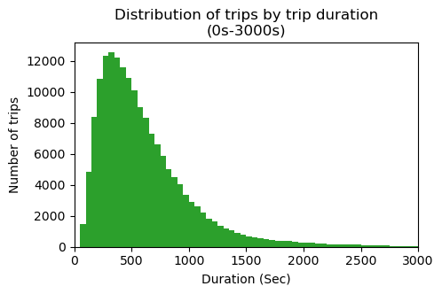

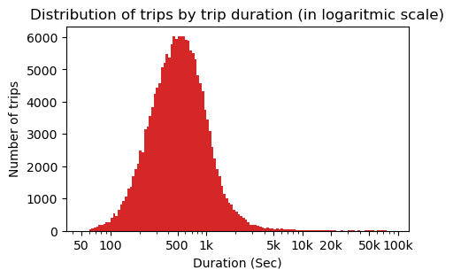

As observed in the previous 2 plots, the duration follows a long-tailed distribution (right distribution). The maximum occurs around 500s. The majority of trips happen in the span of 250s-1000s.

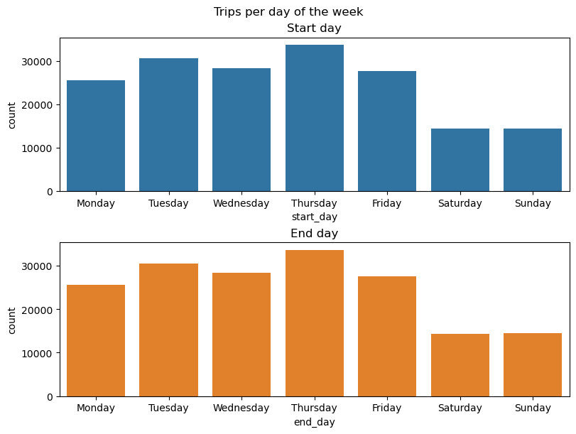

Weekends (Saturdays and Sundays) have the lowest trip records.

## Distribution of Rides by Hours

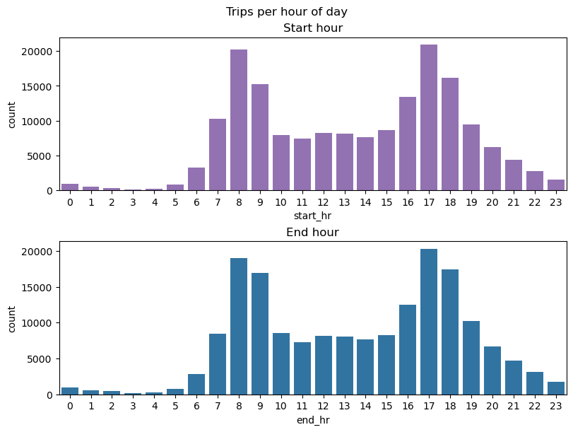

The 8th, 9th, 17th and 18th hours have the highest trip records. This is expected as it can be linked to morning rush and closing hour from work. The 1st, 2nd, 3rd and 4th hours have the least trip records.

## Distribution of Rides by User Type

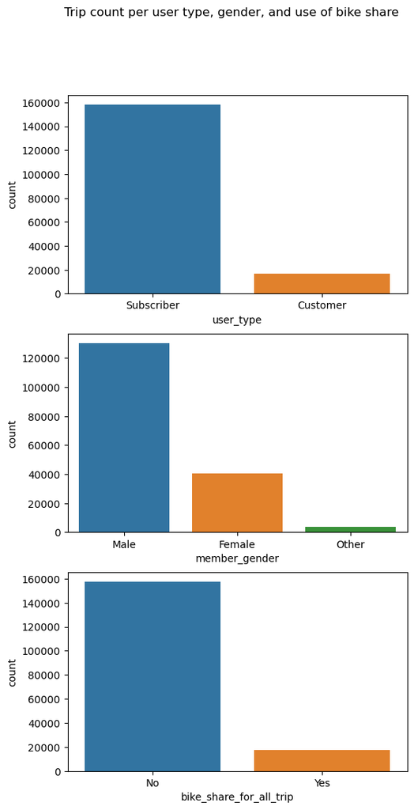

As observed in the 3 plots, the number of subscribers surpasses significantly the number of customers. The numbers of male bikers triples the number of female bikers and the big majority of users don't use bike sharing.

## Bivariate Exploration

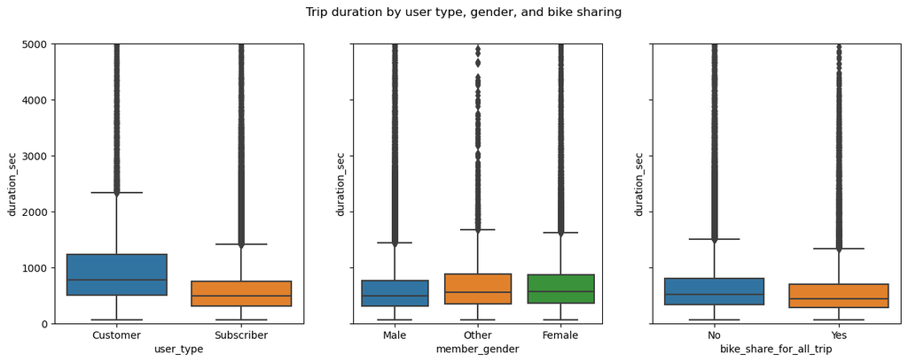

As we saw at the beginning of the study, trip duration is right-skewed with most trips taking a short time and most outliers taking a long time.

When we separate by categories, it appears that customers spend more time on average compared to subscribers, while the female gender spends higher time on average than male.

Bike share for all trip tends to be similar on average across all types.

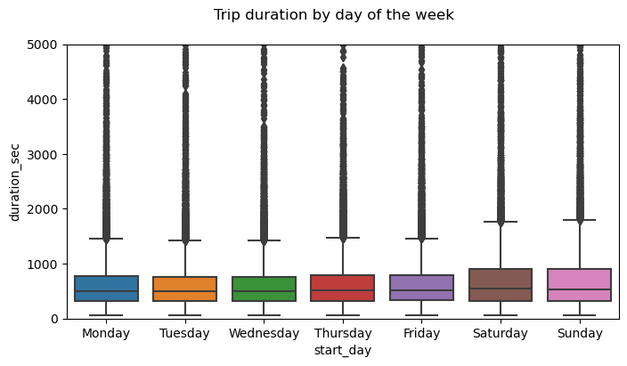

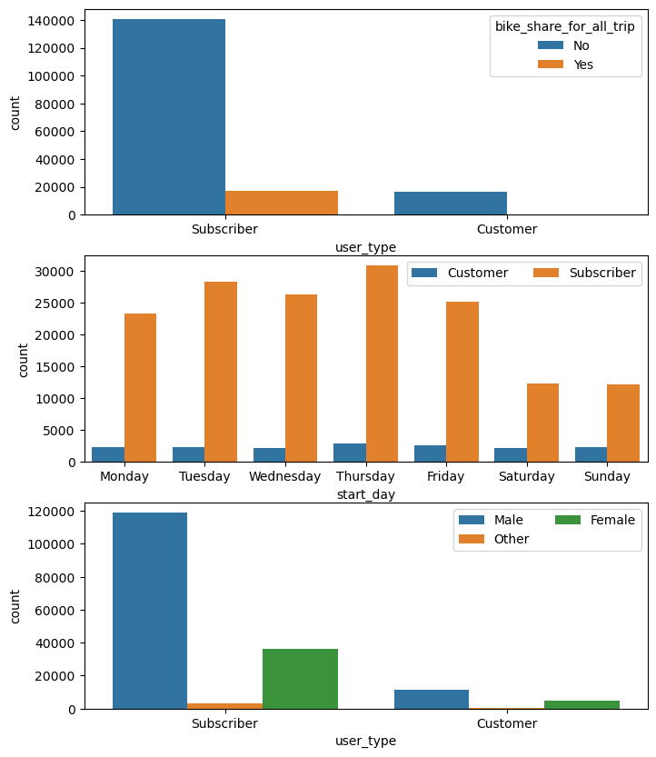

There are no cases of bike sharing for normal customers. It could be that this is a service only available to subscribers.

Normal customers seem to ride equally often all days of the week. Subscribers are likely using the service to go to commute, as their use falls sharply on the weekends.

## Multivariate Exploration

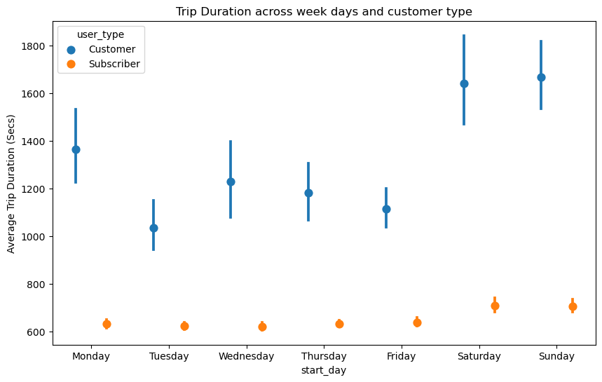

Normal customers travel much longer distances than subscribers.

Both types of customers travel longer distances on weekends than during weekdays, and the increase is more evident for normal customers.

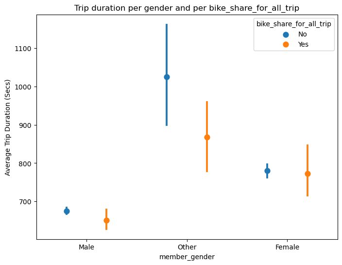

As observed in the graphic, the "Other" member_gender group has longest trip durations for bike sharing and non sharing. Female is the second group with the longest trip duration, followed by male.

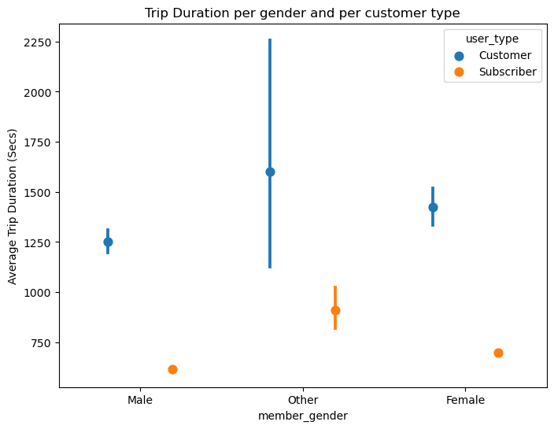

Of all the gender groups, the one that spent the most duration among both subscribers and customers were "Other", followed by female and then male.